# Untitled5 (2)

Artist Dataset

```python
import pandas as pd

data = pd.read_csv('https://raw.githubusercontent.com/rfordatascience/tidytuesday/master/data/2023/2023-01-17/artists.csv',header='infer')
data
```

|  | artist_name | edition_number | year | artist_nationality | artist_nationality_other | artist_gender | artist_race | artist_ethnicity | book | space_ratio_per_page_total | artist_unique_id | moma_count_to_year | whitney_count_to_year | artist_race_nwi |
| --- | --- | --- | --- | --- | --- | --- | --- | --- | --- | --- | --- | --- | --- | --- |
| 0 | Aaron Douglas | 9.0 | 1991 | American | American | Male | Black or African American | Not Hispanic or Latino origin | Gardner | 0.353366 | 2 | 0 | 0 | Non-White |
| 1 | Aaron Douglas | 10.0 | 1996 | American | American | Male | Black or African American | Not Hispanic or Latino origin | Gardner | 0.373947 | 2 | 0 | 0 | Non-White |
| 2 | Aaron Douglas | 11.0 | 2001 | American | American | Male | Black or African American | Not Hispanic or Latino origin | Gardner | 0.303259 | 2 | 0 | 0 | Non-White |
| 3 | Aaron Douglas | 12.0 | 2005 | American | American | Male | Black or African American | Not Hispanic or Latino origin | Gardner | 0.377049 | 2 | 0 | 0 | Non-White |
| 4 | Aaron Douglas | 13.0 | 2009 | American | American | Male | Black or African American | Not Hispanic or Latino origin | Gardner | 0.398410 | 2 | 0 | 0 | Non-White |
| ... | ... | ... | ... | ... | ... | ... | ... | ... | ... | ... | ... | ... | ... | ... |
| 3157 | Winslow Homer | 4.0 | 1991 | American | American | Male | White | Not Hispanic or Latino origin | Janson | 0.377853 | 407 | 1 | 0 | White |
| 3158 | Winslow Homer | 5.0 | 1995 | American | American | Male | White | Not Hispanic or Latino origin | Janson | 0.335776 | 407 | 1 | 0 | White |
| 3159 | Winslow Homer | 6.0 | 2001 | American | American | Male | White | Not Hispanic or Latino origin | Janson | 0.324369 | 407 | 1 | 0 | White |
| 3160 | Winslow Homer | 7.0 | 2007 | American | American | Male | White | Not Hispanic or Latino origin | Janson | 0.323356 | 407 | 1 | 0 | White |
| 3161 | Winslow Homer | 8.0 | 2011 | American | American | Male | White | Not Hispanic or Latino origin | Janson | 0.544094 | 407 | 1 | 0 | White |

3162 rows × 14 columns

```python
data = data[['artist_name','artist_nationality', 'artist_gender', 'artist_race', 'artist_ethnicity', 'moma_count_to_year', 'whitney_count_to_year', 'book']]
```

```python
data
```

|  | artist_name | artist_nationality | artist_gender | artist_race | artist_ethnicity | moma_count_to_year | whitney_count_to_year | book |
| --- | --- | --- | --- | --- | --- | --- | --- | --- |
| 0 | Aaron Douglas | American | Male | Black or African American | Not Hispanic or Latino origin | 0 | 0 | Gardner |
| 1 | Aaron Douglas | American | Male | Black or African American | Not Hispanic or Latino origin | 0 | 0 | Gardner |
| 2 | Aaron Douglas | American | Male | Black or African American | Not Hispanic or Latino origin | 0 | 0 | Gardner |
| 3 | Aaron Douglas | American | Male | Black or African American | Not Hispanic or Latino origin | 0 | 0 | Gardner |
| 4 | Aaron Douglas | American | Male | Black or African American | Not Hispanic or Latino origin | 0 | 0 | Gardner |
| ... | ... | ... | ... | ... | ... | ... | ... | ... |
| 3157 | Winslow Homer | American | Male | White | Not Hispanic or Latino origin | 1 | 0 | Janson |
| 3158 | Winslow Homer | American | Male | White | Not Hispanic or Latino origin | 1 | 0 | Janson |
| 3159 | Winslow Homer | American | Male | White | Not Hispanic or Latino origin | 1 | 0 | Janson |
| 3160 | Winslow Homer | American | Male | White | Not Hispanic or Latino origin | 1 | 0 | Janson |
| 3161 | Winslow Homer | American | Male | White | Not Hispanic or Latino origin | 1 | 0 | Janson |

3162 rows × 8 columns

```python
data.dropna()
```

|  | artist_name | artist_nationality | artist_gender | artist_race | artist_ethnicity | moma_count_to_year | whitney_count_to_year | book |
| --- | --- | --- | --- | --- | --- | --- | --- | --- |
| 0 | Aaron Douglas | American | Male | Black or African American | Not Hispanic or Latino origin | 0 | 0 | Gardner |
| 1 | Aaron Douglas | American | Male | Black or African American | Not Hispanic or Latino origin | 0 | 0 | Gardner |
| 2 | Aaron Douglas | American | Male | Black or African American | Not Hispanic or Latino origin | 0 | 0 | Gardner |
| 3 | Aaron Douglas | American | Male | Black or African American | Not Hispanic or Latino origin | 0 | 0 | Gardner |
| 4 | Aaron Douglas | American | Male | Black or African American | Not Hispanic or Latino origin | 0 | 0 | Gardner |
| ... | ... | ... | ... | ... | ... | ... | ... | ... |
| 3157 | Winslow Homer | American | Male | White | Not Hispanic or Latino origin | 1 | 0 | Janson |
| 3158 | Winslow Homer | American | Male | White | Not Hispanic or Latino origin | 1 | 0 | Janson |
| 3159 | Winslow Homer | American | Male | White | Not Hispanic or Latino origin | 1 | 0 | Janson |
| 3160 | Winslow Homer | American | Male | White | Not Hispanic or Latino origin | 1 | 0 | Janson |
| 3161 | Winslow Homer | American | Male | White | Not Hispanic or Latino origin | 1 | 0 | Janson |

3100 rows × 8 columns

```python
data
```

|  | artist_name | artist_nationality | artist_gender | artist_race | artist_ethnicity | moma_count_to_year | whitney_count_to_year | book |
| --- | --- | --- | --- | --- | --- | --- | --- | --- |
| 0 | Aaron Douglas | American | Male | Black or African American | Not Hispanic or Latino origin | 0 | 0 | Gardner |
| 1 | Aaron Douglas | American | Male | Black or African American | Not Hispanic or Latino origin | 0 | 0 | Gardner |
| 2 | Aaron Douglas | American | Male | Black or African American | Not Hispanic or Latino origin | 0 | 0 | Gardner |
| 3 | Aaron Douglas | American | Male | Black or African American | Not Hispanic or Latino origin | 0 | 0 | Gardner |
| 4 | Aaron Douglas | American | Male | Black or African American | Not Hispanic or Latino origin | 0 | 0 | Gardner |
| ... | ... | ... | ... | ... | ... | ... | ... | ... |
| 3157 | Winslow Homer | American | Male | White | Not Hispanic or Latino origin | 1 | 0 | Janson |
| 3158 | Winslow Homer | American | Male | White | Not Hispanic or Latino origin | 1 | 0 | Janson |
| 3159 | Winslow Homer | American | Male | White | Not Hispanic or Latino origin | 1 | 0 | Janson |
| 3160 | Winslow Homer | American | Male | White | Not Hispanic or Latino origin | 1 | 0 | Janson |
| 3161 | Winslow Homer | American | Male | White | Not Hispanic or Latino origin | 1 | 0 | Janson |

3162 rows × 8 columns

```python
data['artist_nationality'].unique()
```

```
array(['American', 'French', 'German-American', 'Scottish', 'Argentine',
       'Cuban-American', 'Japanese', 'German', 'Swiss',
       'Armenian-American', 'British', 'Russian', 'Danish-French',
       'Brazilian', 'New Zealander', 'Mexican', 'Canadian', 'Latvian',
       'Norwegian', 'Austrian', 'Australian', 'Columbian', 'Spanish',
       'Italian', 'Austrian-American', 'Chinese', 'Belgian',
       'German-French', 'Peruvian', 'Italian-American', 'Thai',
       'Swiss-French', 'Hungarian', 'Russian-French', 'Cuban',
       'Polynesian', nan, 'Indian', 'French Polynesian', 'Swedish',
       'Swiss-German', 'Uruguayan', 'Dutch', 'Pakistani-American',
       'Iranian', 'Korean', 'Congolese', 'Hungarian-French',
       'Dutch-American', 'Czech', 'Danish-American', 'Hungarian-American'],
      dtype=object)
```

```python
data['artist_gender'].unique()
```

```
array(['Male', 'Female', nan], dtype=object)
```

```python
data['artist_race'].unique()
```

```
array(['Black or African American', 'White', 'Asian',
       'Native Hawaiian or Other Pacific Islander', nan,
       'American Indian or Alaska Native'], dtype=object)
```

```python
data['artist_ethnicity'].unique()
```

```
array(['Not Hispanic or Latino origin', 'Hispanic or Latino origin', nan],
      dtype=object)
```

```python
data['moma_count_to_year'].unique()
```

```
array([ 0,  2,  1,  3,  4,  8, 11, 12, 13, 14, 15, 16,  5,  6,  7, 28,  9,
       19, 10, 20, 17, 18, 21, 22, 25, 29, 31, 34, 37, 40, 43, 44, 24, 26,
       27, 48, 56, 57, 59, 60, 63, 64, 33, 35, 32, 23, 36, 41, 45, 46, 30,
       39, 58, 47])
```

```python
data['whitney_count_to_year'].unique()
```

```
array([ 0,  1,  2,  3, 19,  6,  9, 12, 13, 15, 14, 16, 11,  4,  5,  8,  7,
       10, 17, 18, 22, 29, 26, 27, 30, 32, 36, 38, 40, 20, 21, 24, 28, 25,
       23, 31, 34])
```

```python
data['book'].unique()
```

```
array(['Gardner', 'Janson'], dtype=object)
```

```python
data = data.dropna()

# Optionally, you can reset the index if you want consecutive row indices
data = data.reset_index(drop=True)
```

```python
data
```

|  | artist_name | artist_nationality | artist_gender | artist_race | artist_ethnicity | moma_count_to_year | whitney_count_to_year | book |
| --- | --- | --- | --- | --- | --- | --- | --- | --- |
| 0 | Aaron Douglas | American | Male | Black or African American | Not Hispanic or Latino origin | 0 | 0 | Gardner |
| 1 | Aaron Douglas | American | Male | Black or African American | Not Hispanic or Latino origin | 0 | 0 | Gardner |
| 2 | Aaron Douglas | American | Male | Black or African American | Not Hispanic or Latino origin | 0 | 0 | Gardner |
| 3 | Aaron Douglas | American | Male | Black or African American | Not Hispanic or Latino origin | 0 | 0 | Gardner |
| 4 | Aaron Douglas | American | Male | Black or African American | Not Hispanic or Latino origin | 0 | 0 | Gardner |
| ... | ... | ... | ... | ... | ... | ... | ... | ... |
| 3095 | Winslow Homer | American | Male | White | Not Hispanic or Latino origin | 1 | 0 | Janson |
| 3096 | Winslow Homer | American | Male | White | Not Hispanic or Latino origin | 1 | 0 | Janson |
| 3097 | Winslow Homer | American | Male | White | Not Hispanic or Latino origin | 1 | 0 | Janson |
| 3098 | Winslow Homer | American | Male | White | Not Hispanic or Latino origin | 1 | 0 | Janson |
| 3099 | Winslow Homer | American | Male | White | Not Hispanic or Latino origin | 1 | 0 | Janson |

3100 rows × 8 columns

```python
data['artist_nationality'] = data['artist_nationality'].apply(lambda x: "Non-American" if x != "American" else "American")
```

```python
data['artist_nationality'].unique()
```

```
array(['American', 'Non-American'], dtype=object)
```

```python
# Map 'American' to 1 and 'Non-American' to 0
data['artist_nationality'] = data['artist_nationality'].map({'American': 1, 'Non-American': 0})

# Convert the column to float
data['artist_nationality'] = data['artist_nationality'].astype(float)
```

```python
data['artist_gender'] = data['artist_gender'].map({'Male': 1, 'Female': 0})

# Convert the column to float
data['artist_gender'] = data['artist_gender'].astype(float)
```

```python
data['artist_race'] = data['artist_race'].apply(lambda x: "Non-White" if x != "White" else "White")
```

```python
data['artist_race'] = data['artist_race'].map({'White': 1, 'Non-White': 0})

# Convert the column to float
data['artist_race'] = data['artist_race'].astype(float)
```

```python
data['artist_ethnicity'] = data['artist_ethnicity'].map({'Hispanic or Latino origin': 1, 'Not Hispanic or Latino origin': 0})

# Convert the column to float
data['artist_ethnicity'] = data['artist_ethnicity'].astype(float)
```

```python
data
```

|  | artist_name | artist_nationality | artist_gender | artist_race | artist_ethnicity | moma_count_to_year | whitney_count_to_year | book |
| --- | --- | --- | --- | --- | --- | --- | --- | --- |
| 0 | Aaron Douglas | 1.0 | 1.0 | 0.0 | 0.0 | 0 | 0 | Gardner |
| 1 | Aaron Douglas | 1.0 | 1.0 | 0.0 | 0.0 | 0 | 0 | Gardner |
| 2 | Aaron Douglas | 1.0 | 1.0 | 0.0 | 0.0 | 0 | 0 | Gardner |
| 3 | Aaron Douglas | 1.0 | 1.0 | 0.0 | 0.0 | 0 | 0 | Gardner |
| 4 | Aaron Douglas | 1.0 | 1.0 | 0.0 | 0.0 | 0 | 0 | Gardner |
| ... | ... | ... | ... | ... | ... | ... | ... | ... |
| 3095 | Winslow Homer | 1.0 | 1.0 | 1.0 | 0.0 | 1 | 0 | Janson |
| 3096 | Winslow Homer | 1.0 | 1.0 | 1.0 | 0.0 | 1 | 0 | Janson |
| 3097 | Winslow Homer | 1.0 | 1.0 | 1.0 | 0.0 | 1 | 0 | Janson |
| 3098 | Winslow Homer | 1.0 | 1.0 | 1.0 | 0.0 | 1 | 0 | Janson |
| 3099 | Winslow Homer | 1.0 | 1.0 | 1.0 | 0.0 | 1 | 0 | Janson |

3100 rows × 8 columns

```python
pd.crosstab([data['artist_nationality'], data['artist_gender']], data['book'])
```

| artist_nationality | book artist_gender | Gardner | Janson |
| --- | --- | --- | --- |
| 0.0 | 0.0 | 115 | 48 |
|  | 1.0 | 1227 | 817 |
| 1.0 | 0.0 | 101 | 74 |
|  | 1.0 | 438 | 280 |

In the data preprocessing steps, we focused on cleaning and transforming the dataset. We selected a subset of columns related to artists, their attributes, and exhibition counts at different museums. After dropping missing values, we converted several categorical variables into binary representations, making them suitable for analysis. Notably, we categorized artist nationality as either "American" or "Non-American" and represented it as binary values (1 for American and 0 for non-American).

The subsequent cross-tabulation analysis examines the relationship between artist nationality, gender, and the choice of art history book (Janson or Gardner).

- Non-American artists: Gardner features more Non-American artists compared to Janson
- American artists: Gardner has a greater representation of American artists.
- Non-Male artists: Gardner has more Non-Male artists in both Non-American and American categories.
- Male artists: Gardner also features more Male artists in both Non-American and American categories.

**Decision Tree Classifier**

```python
from sklearn import tree
Y = data['book']
X = data[['artist_nationality', 'artist_gender', 'artist_race', 'artist_ethnicity', 'moma_count_to_year', 'whitney_count_to_year']]

# Create a decision tree classifier object with entropy as the impurity measure and a maximum depth of 3
clf = tree.DecisionTreeClassifier(criterion='entropy', max_depth=3)

# Train the classifier on the labeled data
clf = clf.fit(X, Y)
```

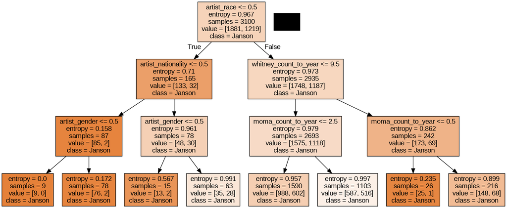

```python
import pydotplus
from IPython.display import Image

dot_data = tree.export_graphviz(clf, feature_names=X.columns, class_names=['Janson', 'Gardner'], filled=True, out_file=None)

# Create the decision tree graph
graph = pydotplus.graph_from_dot_data(dot_data)

# Display the decision tree graph
Image(graph.create_png())
```

```python
testData = [['Cristiano Ronaldo',0,0,0,0,1,1,'Gardner'],
           ['Lionel Messi',1,0,0,0,1,1,'Janson'],
           ['Neymar Jr',1,0,0,1,1,0,'Gardner'],
           ['Kylian Mbappe',1,1,1,0,0,0,'Janson']]
testData = pd.DataFrame(testData, columns=data.columns)
testData
```

|  | artist_name | artist_nationality | artist_gender | artist_race | artist_ethnicity | moma_count_to_year | whitney_count_to_year | book |
| --- | --- | --- | --- | --- | --- | --- | --- | --- |
| 0 | Cristiano Ronaldo | 0 | 0 | 0 | 0 | 1 | 1 | Gardner |
| 1 | Lionel Messi | 1 | 0 | 0 | 0 | 1 | 1 | Janson |
| 2 | Neymar Jr | 1 | 0 | 0 | 1 | 1 | 0 | Gardner |
| 3 | Kylian Mbappe | 1 | 1 | 1 | 0 | 0 | 0 | Janson |

```python
testY = testData['book']
testX = testData.drop(['artist_name', 'book'], axis=1)

# Make predictions using the decision tree classifier
predY = clf.predict(testX)

# Create a DataFrame with artist names and predicted classes
predictions = pd.DataFrame({'artist_name': testData['artist_name'], 'Predicted_book': predY})

# Display the predictions
predictions
```

|  | artist_name | Predicted_book |
| --- | --- | --- |
| 0 | Cristiano Ronaldo | Gardner |
| 1 | Lionel Messi | Gardner |
| 2 | Neymar Jr | Gardner |
| 3 | Kylian Mbappe | Gardner |

```python
from sklearn.metrics import accuracy_score

print('Accuracy on test data is %.2f' % (accuracy_score(testY, predY)))
```

```
Accuracy on test data is 0.50
```

1. Decision Tree Creation: Imported the necessary libraries, including 'sklearn' for decision tree construction. Prepared your dataset, specifying the target variable ('Y') as 'book' and the features ('X') as various artist attributes. A decision tree classifier was created with entropy as the impurity criterion and a maximum depth of 3. The classifier was trained on the labeled data.
2. Visualization: You used 'pydotplus' and 'Image' from 'IPython.display' to visualize the decision tree. The decision tree was generated and displayed as a graph.
3. Testing: You created a test dataset with artist information and the corresponding book labels. Predictions were made using the trained decision tree classifier for this test dataset.
4. Accuracy: The accuracy of the model on the test data was calculated using 'accuracy_score' from 'sklearn.metrics.' The accuracy is reported as 0.50 (50%).
5. Interpretation: Decision tree classifier has been trained and applied to a small test dataset. The accuracy of 0.50 indicates that the model correctly predicted the books for half of the test instances. Further analysis and fine-tuning of the model may be necessary to improve its performance. Additionally, you may want to use a larger and more representative dataset for more robust evaluations.

```python
"""import numpy as np
import matplotlib.pyplot as plt
from numpy.random import random


N = 1500

mean1 = [6, 14]
mean2 = [10, 6]
mean3 = [14, 14]
cov = [[3.5, 0], [0, 3.5]]  # diagonal covariance

np.random.seed(50)
X = np.random.multivariate_normal(mean1, cov, int(N/6))
X = np.concatenate((X, np.random.multivariate_normal(mean2, cov, int(N/6))))
X = np.concatenate((X, np.random.multivariate_normal(mean3, cov, int(N/6))))
X = np.concatenate((X, 20*np.random.rand(int(N/2),2)))
Y = np.concatenate((np.ones(int(N/2)),np.zeros(int(N/2))))

plt.plot(X[:int(N/2),0],X[:int(N/2),1],'r+',X[int(N/2):,0],X[int(N/2):,1],'k.',ms=4)"""
```

[output not shown]

Model Overfitting

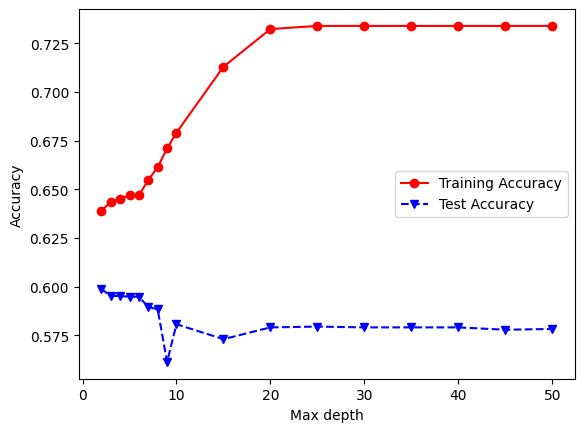

```python
#########################################
# Training and Test set creation
#########################################

from sklearn.model_selection import train_test_split
X_train, X_test, Y_train, Y_test = train_test_split(X, Y, test_size=0.8, random_state=1)
import numpy as np
from sklearn import tree
import matplotlib.pyplot as plt
from sklearn.metrics import accuracy_score

#########################################
# Model fitting and evaluation
#########################################

maxdepths = [2,3,4,5,6,7,8,9,10,15,20,25,30,35,40,45,50]

trainAcc = np.zeros(len(maxdepths))
testAcc = np.zeros(len(maxdepths))

index = 0
for depth in maxdepths:
    clf = tree.DecisionTreeClassifier(max_depth=depth)
    clf = clf.fit(X_train, Y_train)
    Y_predTrain = clf.predict(X_train)
    Y_predTest = clf.predict(X_test)
    trainAcc[index] = accuracy_score(Y_train, Y_predTrain)
    testAcc[index] = accuracy_score(Y_test, Y_predTest)
    index += 1

#########################################
# Plot of training and test accuracies
#########################################

plt.plot(maxdepths,trainAcc,'ro-',maxdepths,testAcc,'bv--')
plt.legend(['Training Accuracy','Test Accuracy'])
plt.xlabel('Max depth')
plt.ylabel('Accuracy')
```

K-nearest neighbor classifier

```python
from sklearn.neighbors import KNeighborsClassifier
import matplotlib.pyplot as plt

numNeighbors = [1, 5, 10, 15, 20, 25, 30]
trainAcc = []
testAcc = []

for k in numNeighbors:
    clf = KNeighborsClassifier(n_neighbors=k, metric='minkowski', p=2)
    clf.fit(X_train, Y_train)
    Y_predTrain = clf.predict(X_train)
    Y_predTest = clf.predict(X_test)
    trainAcc.append(accuracy_score(Y_train, Y_predTrain))
    testAcc.append(accuracy_score(Y_test, Y_predTest))
```

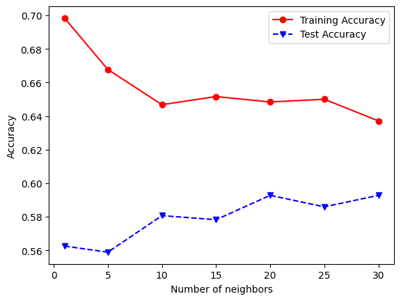

```python
plt.plot(numNeighbors, trainAcc, 'ro-', numNeighbors, testAcc,'bv--')
plt.legend(['Training Accuracy','Test Accuracy'])
plt.xlabel('Number of neighbors')
plt.ylabel('Accuracy')
```

The plot helps in understanding how the choice of the number of neighbors affects the KNN model's performance.

Generally, as the number of neighbors increases, the model may become more robust but less sensitive to local variations in the data.

The goal is to find a balance where the model generalizes well to new data (test accuracy is high) without overfitting to the training data (training accuracy is not excessively high).

The plot allows for the identification of an optimal number of neighbors that maximizes test accuracy.

**Linear Classifier**

```python
from sklearn import linear_model
from sklearn.svm import SVC

C = [0.01, 0.1, 0.2, 0.5, 0.8, 1, 5, 10, 20, 50]
LRtrainAcc = []
LRtestAcc = []
SVMtrainAcc = []
SVMtestAcc = []

for param in C:
    clf = linear_model.LogisticRegression(C=param)
    clf.fit(X_train, Y_train)
    Y_predTrain = clf.predict(X_train)
    Y_predTest = clf.predict(X_test)
    LRtrainAcc.append(accuracy_score(Y_train, Y_predTrain))
    LRtestAcc.append(accuracy_score(Y_test, Y_predTest))

    clf = SVC(C=param,kernel='linear')
    clf.fit(X_train, Y_train)
    Y_predTrain = clf.predict(X_train)
    Y_predTest = clf.predict(X_test)
    SVMtrainAcc.append(accuracy_score(Y_train, Y_predTrain))
    SVMtestAcc.append(accuracy_score(Y_test, Y_predTest))
```

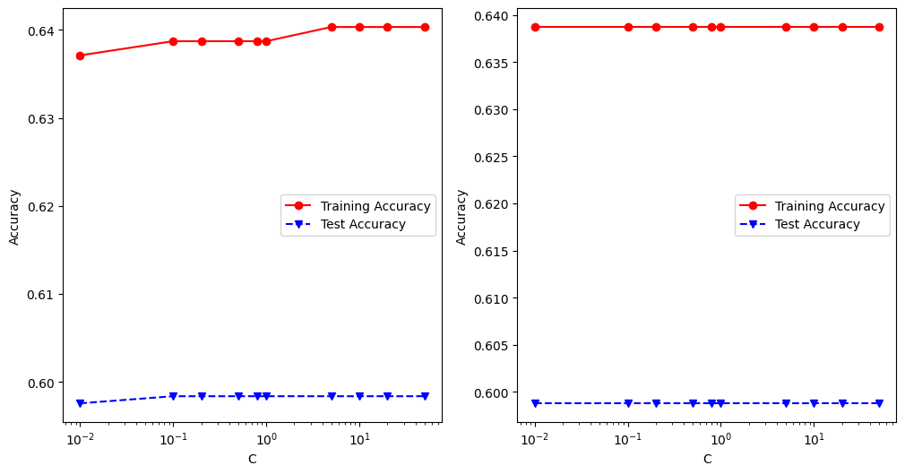

```python
fig, (ax1, ax2) = plt.subplots(1, 2, figsize=(12,6))
ax1.plot(C, LRtrainAcc, 'ro-', C, LRtestAcc,'bv--')
ax1.legend(['Training Accuracy','Test Accuracy'])
ax1.set_xlabel('C')
ax1.set_xscale('log')
ax1.set_ylabel('Accuracy')

ax2.plot(C, SVMtrainAcc, 'ro-', C, SVMtestAcc,'bv--')
ax2.legend(['Training Accuracy','Test Accuracy'])
ax2.set_xlabel('C')
ax2.set_xscale('log')
ax2.set_ylabel('Accuracy')
```

Logistic Regression (LR) and SVM models are trained and tested for various 'C' values.

Training and test accuracies for both LR and SVM are recorded.

Plots display how accuracy changes with 'C' values on a logarithmic scale.

The goal is to identify the 'C' value that optimizes test accuracy while avoiding overfitting on the training set.

Non Linear SVM

```python
from sklearn.svm import SVC

C = [0.01, 0.1, 0.2, 0.5, 0.8, 1, 5, 10, 20, 50]
SVMtrainAcc = []
SVMtestAcc = []

for param in C:
    clf = SVC(C=param,kernel='rbf',gamma='auto')
    clf.fit(X_train, Y_train)
    Y_predTrain = clf.predict(X_train)
    Y_predTest = clf.predict(X_test)
    SVMtrainAcc.append(accuracy_score(Y_train, Y_predTrain))
    SVMtestAcc.append(accuracy_score(Y_test, Y_predTest))
```

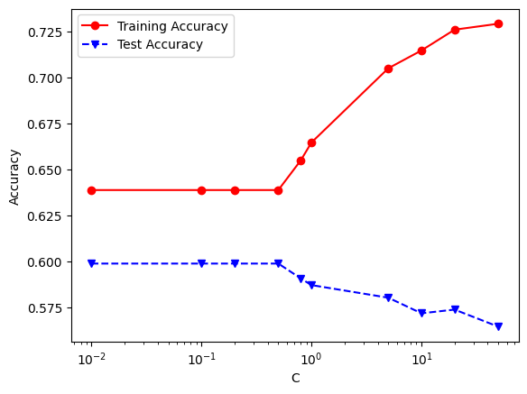

```python
plt.plot(C, SVMtrainAcc, 'ro-', C, SVMtestAcc,'bv--')
plt.legend(['Training Accuracy','Test Accuracy'])
plt.xlabel('C')
plt.xscale('log')
plt.ylabel('Accuracy')
```

The plot helps assess how the regularization parameter 'C' influences the performance of the SVM model with an RBF kernel.

The log scale on the x-axis allows for a clearer view of the entire range of 'C' values.

The goal is to identify the 'C' value that optimizes test accuracy without overfitting on the training set.

Ensemble Methods

```python
from sklearn import ensemble
from sklearn.tree import DecisionTreeClassifier

numBaseClassifiers = 500
maxdepth = 10
trainAcc = []
testAcc = []

clf = ensemble.RandomForestClassifier(n_estimators=numBaseClassifiers)
clf.fit(X_train, Y_train)
```

```
RandomForestClassifier(n_estimators=500)
```

```python
Y_predTrain = clf.predict(X_train)
Y_predTest = clf.predict(X_test)
trainAcc.append(accuracy_score(Y_train, Y_predTrain))
testAcc.append(accuracy_score(Y_test, Y_predTest))

clf = ensemble.BaggingClassifier(DecisionTreeClassifier(max_depth=maxdepth),n_estimators=numBaseClassifiers)
clf.fit(X_train, Y_train)
```

```
BaggingClassifier(estimator=DecisionTreeClassifier(max_depth=10),
                  n_estimators=500)
```

```python
Y_predTrain = clf.predict(X_train)
Y_predTest = clf.predict(X_test)
trainAcc.append(accuracy_score(Y_train, Y_predTrain))
testAcc.append(accuracy_score(Y_test, Y_predTest))

clf = ensemble.AdaBoostClassifier(DecisionTreeClassifier(max_depth=maxdepth),n_estimators=numBaseClassifiers)
clf.fit(X_train, Y_train)
```

```
AdaBoostClassifier(estimator=DecisionTreeClassifier(max_depth=10),
                   n_estimators=500)
```

[output not shown]

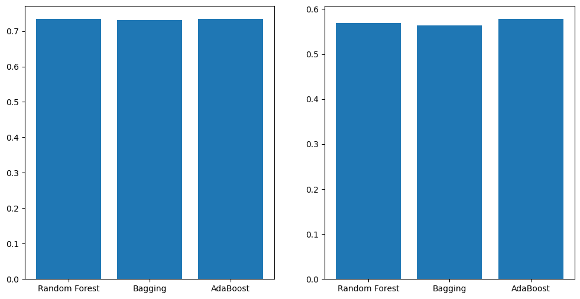

```python
Y_predTrain = clf.predict(X_train)
Y_predTest = clf.predict(X_test)
trainAcc.append(accuracy_score(Y_train, Y_predTrain))
testAcc.append(accuracy_score(Y_test, Y_predTest))

methods = ['Random Forest', 'Bagging', 'AdaBoost']
fig, (ax1, ax2) = plt.subplots(1, 2, figsize=(12,6))
ax1.bar([1.5,2.5,3.5], trainAcc)
ax1.set_xticks([1.5,2.5,3.5])
ax1.set_xticklabels(methods)
ax2.bar([1.5,2.5,3.5], testAcc)
ax2.set_xticks([1.5,2.5,3.5])
ax2.set_xticklabels(methods)
```

The models are trained and evaluated on training and test sets.

Bar plots illustrate the accuracy of each ensemble method.

The goal is to identify the method with the highest test accuracy, offering insights into their effectiveness.